# ModelsForMultivariateData_lab

Ziyi Li

2022-11-15

Tutorial credit goes to <“https://online.stat.psu.edu/stat504/lesson/8/8.2/8.2.2”>, <“https://online.stat.psu.edu/stat504/book/export/html/790”>, and <“https://users.stat.ufl.edu/~aa/ordinal/R_examples.pdf”>.

## Introduction

As we learned, multinomial model is a type of GLM, so the overall goodness-of-fit statistics and their interpretations and limitations from the first and section of the course still apply.

In SAS, we can easily fitted using PROC LOGISTIC with the link=GLOGIT. We can also use PROC CATMOD and GENMOD. You can use the link to the psu slides to learn about the deatiled usage.

In R there are various packages and function for fitting this model. For example, vglm() from VGAM package, ormultinom() from nnet package, or mlogit() from globaltest package from BIOCONDUCTOR. We will focus on using vglm() in this lab illustration.

# Baseline-Category Logit Model

## Get data

We will use the alligator data as discussed in class. Researchersclassified the stomach contents of 219 captured alligators into five categories: Fish (the most common primary food choice), Invertebrate (snails, insects, crayfish, etc.), Reptile (turtles, alligators), Bird, and Other (amphibians, plants, household pets, stones, and other debris). In addition to size and lake, the covariates also contain gender of the alligators.

```r
gator <- read.table(file = "gator.txt", header = TRUE)
head(gator)
```

```
##   profile Gender Size    Lake Fish Invertebrate Reptile Bird Other
## 1       1      f <2.3  george    3            9       1    0     1
## 2       2      m <2.3  george   13           10       0    2     2
## 3       3      f >2.3  george    8            1       0    0     1
## 4       4      m >2.3  george    9            0       0    1     2
## 5       5      f <2.3 hancock   16            3       2    2     3
## 6       6      m <2.3 hancock    7            1       0    0     5
```

```r
dim(gator)
```

```
## [1] 16  9
```

```r
gator <- as.data.frame(gator)
```

Note that the data has already been input as a summary table, which is more convenient for the analysis in R. However, in SAS, it may be better to input the table as single observations like:

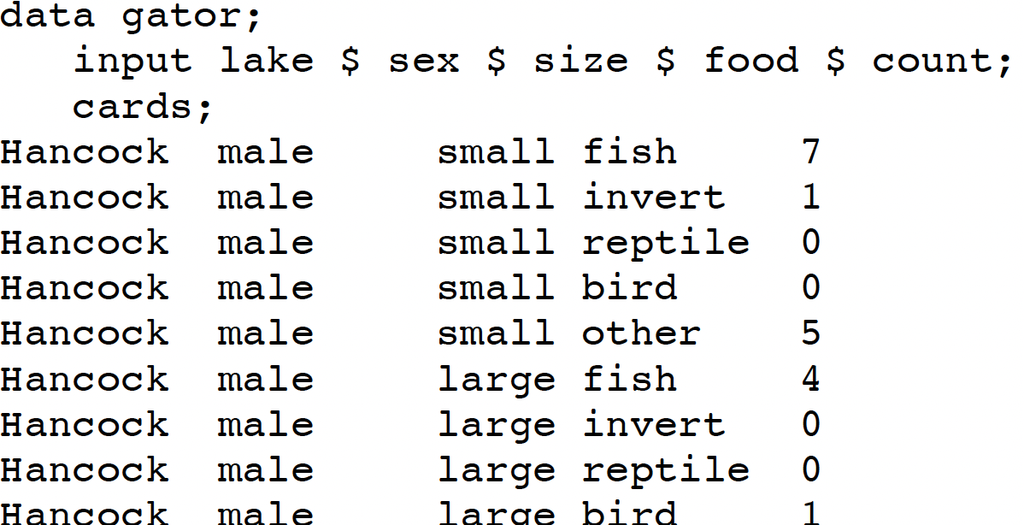

## Specifying baseline-category logit model

Because the usual primary food choice of alligators appears to be fish, we still use fish as the reference level, as we discussed in class.

```r
### if you haven't install VGAM
# install.packages("VGAM")
library(VGAM)
gator$Lake <- factor(gator$Lake, levels = unique(gator$Lake))
levels(gator$Lake)
```

```
## [1] "george"   "hancock"  "oklawaha" "trafford"
```

```r
contrasts(gator$Lake)=contr.treatment(levels(gator$Lake),base=1)

contrasts(gator$Lake)
```

```
##          hancock oklawaha trafford
## george         0        0        0
## hancock        1        0        0
## oklawaha       0        1        0
## trafford       0        0        1
```

To set up *$“fish” as the baseline**, this can be done in the vglm() call. By default vglm() will use the last category to create the logits. Let see how this is done if we want to fit a model with Lake, Size and Gender as predictors and ‘Fish’ as the baseline for logits:

```r
fit1=vglm(cbind(Bird,Invertebrate,Reptile,Other,Fish)~Lake+Size+Gender, data=gator, family=multinomial)
summary(fit1)
```

```
##
## Call:
## vglm(formula = cbind(Bird, Invertebrate, Reptile, Other, Fish) ~
##     Lake + Size + Gender, family = multinomial, data = gator)
##
## Coefficients:
##                Estimate Std. Error z value Pr(>|z|)
## (Intercept):1  -2.43211    0.77066      NA       NA
## (Intercept):2   0.16902    0.37875   0.446  0.65541
## (Intercept):3  -3.41604    1.08513      NA       NA
## (Intercept):4  -1.43073    0.53809  -2.659  0.00784 **
## Lakehancock:1   0.57527    0.79522   0.723  0.46943
## Lakehancock:2  -1.78051    0.62321  -2.857  0.00428 **
## Lakehancock:3   1.12946    1.19280   0.947  0.34369
## Lakehancock:4   0.76658    0.56855   1.348  0.17756
## Lakeoklawaha:1 -0.55035    1.20980  -0.455  0.64917
## Lakeoklawaha:2  0.91318    0.47612   1.918  0.05511 .
## Lakeoklawaha:3  2.53026    1.12211   2.255  0.02414 *
## Lakeoklawaha:4  0.02606    0.77776   0.034  0.97327
## Laketrafford:1  1.23699    0.86610   1.428  0.15322
## Laketrafford:2  1.15582    0.49279   2.345  0.01900 *
## Laketrafford:3  3.06105    1.12972   2.710  0.00674 **
## Laketrafford:4  1.55776    0.62567   2.490  0.01278 *
## Size>2.3:1      0.73024    0.65228   1.120  0.26292
## Size>2.3:2     -1.33626    0.41119  -3.250  0.00116 **
## Size>2.3:3      0.55704    0.64661   0.861  0.38898
## Size>2.3:4     -0.29058    0.45993  -0.632  0.52751
## Genderm:1      -0.60643    0.68884  -0.880  0.37867
## Genderm:2      -0.46296    0.39552  -1.171  0.24180
## Genderm:3      -0.62756    0.68528  -0.916  0.35978
## Genderm:4      -0.25257    0.46635  -0.542  0.58810
## ---
## Signif. codes:  0 '***' 0.001 '**' 0.01 '*' 0.05 '.' 0.1 ' ' 1
##
## Names of linear predictors: log(mu[,1]/mu[,5]), log(mu[,2]/mu[,5]),
## log(mu[,3]/mu[,5]), log(mu[,4]/mu[,5])
##
## Residual deviance: 50.2637 on 40 degrees of freedom
##
## Log-likelihood: -73.3221 on 40 degrees of freedom
##
## Number of Fisher scoring iterations: 5
##
## Warning: Hauck-Donner effect detected in the following estimate(s):
## '(Intercept):1', '(Intercept):3'
##
##
## Reference group is level  5  of the response
```

## check goodness of fit

```r
# deviance test for lack of fit
g2 = deviance(fit1)
df = df.residual(fit1)
1 - pchisq(g2, df)
```

```
## [1] 0.128185
```

```r
# pearson test for lack of fit
e = residuals(fit1, type='pearson')
x2 = sum(e^2)
1 - pchisq(x2, df)
```

```
## [1] 0.08809151
```

```r
# ANOVA for lack of fit
anova(fit1, type=3, test="LR")
```

```
## Analysis of Deviance Table (Type III tests: each term added last)
##
## Model: 'multinomial', 'VGAMcategorical'
##
## Link: 'multilogitlink'
##
## Response: cbind(Bird, Invertebrate, Reptile, Other, Fish)
##
##        Df Deviance Resid. Df Resid. Dev  Pr(>Chi)
## Lake   12   50.318        52    100.582 1.228e-06 ***
## Size    4   17.600        44     67.864  0.001477 **
## Gender  4    2.215        44     52.478  0.696321
## ---
## Signif. codes:  0 '***' 0.001 '**' 0.01 '*' 0.05 '.' 0.1 ' ' 1
```

```r
step4vglm(fit1, direction='backward')
```

```
## Start:  AIC=194.64
## cbind(Bird, Invertebrate, Reptile, Other, Fish) ~ Lake + Size +
##     Gender
##
##          Df Deviance    AIC
## - Gender  4   52.478 188.86
## <none>        50.264 194.64
## - Size    4   67.864 204.24
## - Lake   12  100.582 220.96
##
## Step:  AIC=188.86
## cbind(Bird, Invertebrate, Reptile, Other, Fish) ~ Lake + Size
##
##        Df Deviance    AIC
## <none>      52.478 188.86
## - Size  4   73.566 201.95
## - Lake 12  101.612 213.99
```

```
##
## Call:
## vglm(formula = cbind(Bird, Invertebrate, Reptile, Other, Fish) ~
##     Lake + Size, family = multinomial, data = gator)
##
##
## Coefficients:
##  (Intercept):1  (Intercept):2  (Intercept):3  (Intercept):4  Lakehancock:1
##   -2.723736492   -0.090813981   -3.665795503   -1.572721367    0.695117558
##  Lakehancock:2  Lakehancock:3  Lakehancock:4 Lakeoklawaha:1 Lakeoklawaha:2
##   -1.658358598    1.242776619    0.826196212   -0.653207709    0.937219322
## Lakeoklawaha:3 Lakeoklawaha:4 Laketrafford:1 Laketrafford:2 Laketrafford:3
##    2.458871961    0.005653062    1.087766759    1.121984830    2.935253308
## Laketrafford:4     Size>2.3:1     Size>2.3:2     Size>2.3:3     Size>2.3:4
##    1.516368733    0.630659731   -1.458204620    0.351262840   -0.331550262
##
## Degrees of Freedom: 64 Total; 44 Residual
## Residual deviance: 52.47849
## Log-likelihood: -74.42948
##
## This is a multinomial logit model with 5 levels
```

## Get a reduced model

```r
fit2=vglm(cbind(Bird,Invertebrate,Reptile,Other,Fish)~Lake+Size, data=gator, family=multinomial)
summary(fit2)
```

```
##
## Call:
## vglm(formula = cbind(Bird, Invertebrate, Reptile, Other, Fish) ~
##     Lake + Size, family = multinomial, data = gator)
##
## Coefficients:
##                 Estimate Std. Error z value Pr(>|z|)
## (Intercept):1  -2.723736   0.710393  -3.834 0.000126 ***
## (Intercept):2  -0.090814   0.308039  -0.295 0.768136
## (Intercept):3  -3.665796   1.058958  -3.462 0.000537 ***
## (Intercept):4  -1.572721   0.474822  -3.312 0.000926 ***
## Lakehancock:1   0.695118   0.781263   0.890 0.373608
## Lakehancock:2  -1.658359   0.612877  -2.706 0.006813 **
## Lakehancock:3   1.242777   1.185418   1.048 0.294461
## Lakehancock:4   0.826196   0.557541   1.482 0.138378
## Lakeoklawaha:1 -0.653208   1.201917  -0.543 0.586805
## Lakeoklawaha:2  0.937219   0.471905   1.986 0.047030 *
## Lakeoklawaha:3  2.458872   1.118113   2.199 0.027869 *
## Lakeoklawaha:4  0.005653   0.776571   0.007 0.994192
## Laketrafford:1  1.087767   0.841669   1.292 0.196221
## Laketrafford:2  1.121985   0.490513   2.287 0.022174 *
## Laketrafford:3  2.935253   1.116395   2.629 0.008558 **
## Laketrafford:4  1.516369   0.621435   2.440 0.014683 *
## Size>2.3:1      0.630660   0.642473   0.982 0.326291
## Size>2.3:2     -1.458205   0.395945  -3.683 0.000231 ***
## Size>2.3:3      0.351263   0.580032   0.606 0.544785
## Size>2.3:4     -0.331550   0.448252  -0.740 0.459511
## ---
## Signif. codes:  0 '***' 0.001 '**' 0.01 '*' 0.05 '.' 0.1 ' ' 1
##
## Names of linear predictors: log(mu[,1]/mu[,5]), log(mu[,2]/mu[,5]),
## log(mu[,3]/mu[,5]), log(mu[,4]/mu[,5])
##
## Residual deviance: 52.4785 on 44 degrees of freedom
##
## Log-likelihood: -74.4295 on 44 degrees of freedom
##
## Number of Fisher scoring iterations: 5
##
## Warning: Hauck-Donner effect detected in the following estimate(s):
## '(Intercept):1', '(Intercept):3'
##
##
## Reference group is level  5  of the response
```

```r
# goodness of fit again:
anova(fit2, type=3, test="LR")
```

```
## Analysis of Deviance Table (Type III tests: each term added last)
##
## Model: 'multinomial', 'VGAMcategorical'
##
## Link: 'multilogitlink'
##
## Response: cbind(Bird, Invertebrate, Reptile, Other, Fish)
##
##      Df Deviance Resid. Df Resid. Dev  Pr(>Chi)
## Lake 12   49.133        56    101.612 1.983e-06 ***
## Size  4   21.087        48     73.566 0.0003043 ***
## ---
## Signif. codes:  0 '***' 0.001 '**' 0.01 '*' 0.05 '.' 0.1 ' ' 1
```

```r
exp(coef(fit2))
```

```
##  (Intercept):1  (Intercept):2  (Intercept):3  (Intercept):4  Lakehancock:1
##     0.06562907     0.91318756     0.02558381     0.20747978     2.00394464
##  Lakehancock:2  Lakehancock:3  Lakehancock:4 Lakeoklawaha:1 Lakeoklawaha:2
##     0.19045133     3.46522172     2.28461201     0.52037389     2.55287282
## Lakeoklawaha:3 Lakeoklawaha:4 Laketrafford:1 Laketrafford:2 Laketrafford:3
##    11.69161550     1.00566907     2.96763921     3.07094346    18.82627137
## Laketrafford:4     Size>2.3:1     Size>2.3:2     Size>2.3:3     Size>2.3:4
##     4.55565233     1.87884971     0.23265360     1.42086074     0.71781008
```

```r
# get 95% CI
exp(confint(fit2))
```

```
##                      2.5 %      97.5 %
## (Intercept):1  0.016308295   0.2641095
## (Intercept):2  0.499294643   1.6701792
## (Intercept):3  0.003210546   0.2038692
## (Intercept):4  0.081809998   0.5261932
## Lakehancock:1  0.433384227   9.2661289
## Lakehancock:2  0.057293051   0.6330909
## Lakehancock:3  0.339391678  35.3802474
## Lakehancock:4  0.766007515   6.8138392
## Lakeoklawaha:1 0.049344808   5.4876894
## Lakeoklawaha:2 1.012378069   6.4374761
## Lakeoklawaha:3 1.306577452 104.6198011
## Lakeoklawaha:4 0.219500868   4.6075912
## Laketrafford:1 0.570139801  15.4468825
## Laketrafford:2 1.174212433   8.0315056
## Laketrafford:3 2.110996559 167.8962916
## Laketrafford:4 1.347672314  15.3998624
## Size>2.3:1     0.533357175   6.6185970
## Size>2.3:2     0.107073285   0.5055201
## Size>2.3:3     0.455856079   4.4286899
## Size>2.3:4     0.298165194   1.7280733
```

# Cumulative Logit Model

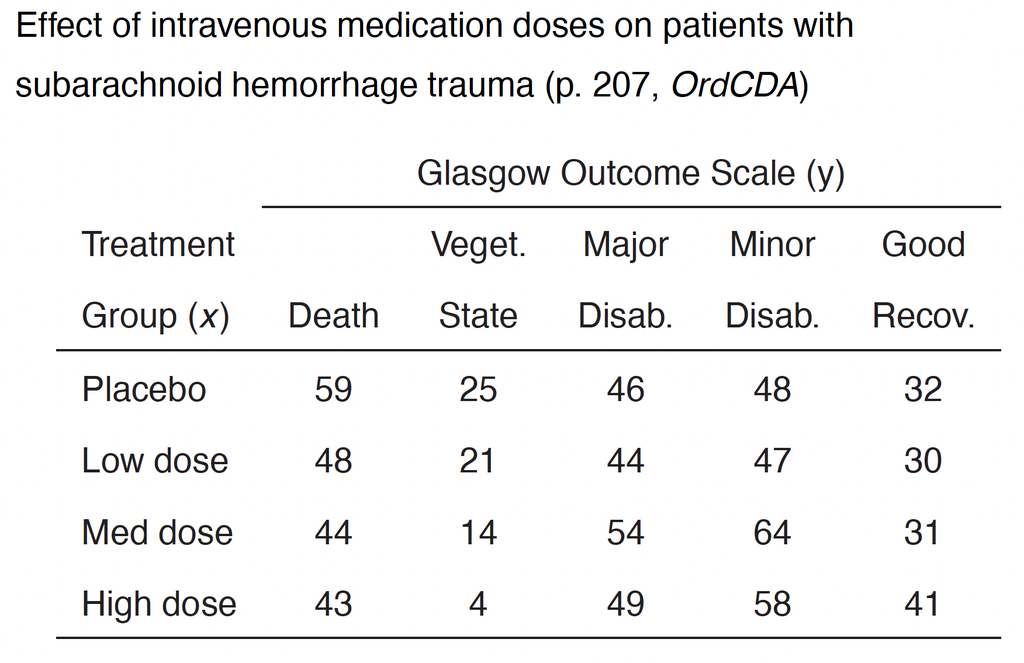

Let’s model with linear effect of dose (scores x = 1, 2, 3, 4) on cumulative logits for outcome.

```r
trauma <- read.table("trauma.txt", header=TRUE)
head(trauma)
```

```
##   dose y1 y2 y3 y4 y5
## 1    1 59 25 46 48 32
## 2    2 48 21 44 47 30
## 3    3 44 14 54 64 31
## 4    4 43  4 49 58 41
```

```r
library(VGAM)
fit <- vglm(cbind(y1,y2,y3,y4,y5) ~ dose, family=cumulative(parallel=TRUE), data=trauma)
summary(fit)
```

```
##
## Call:
## vglm(formula = cbind(y1, y2, y3, y4, y5) ~ dose, family = cumulative(parallel = TRUE),
##     data = trauma)
##
## Coefficients:
##               Estimate Std. Error z value Pr(>|z|)
## (Intercept):1 -0.71917    0.15881  -4.528 5.94e-06 ***
## (Intercept):2 -0.31860    0.15642  -2.037  0.04167 *
## (Intercept):3  0.69165    0.15793   4.380 1.19e-05 ***
## (Intercept):4  2.05700    0.17369  11.843  < 2e-16 ***
## dose          -0.17548    0.05632  -3.116  0.00183 **
## ---
## Signif. codes:  0 '***' 0.001 '**' 0.01 '*' 0.05 '.' 0.1 ' ' 1
##
## Names of linear predictors: logitlink(P[Y<=1]), logitlink(P[Y<=2]),
## logitlink(P[Y<=3]), logitlink(P[Y<=4])
##
## Residual deviance: 18.1825 on 11 degrees of freedom
##
## Log-likelihood: -48.8728 on 11 degrees of freedom
##
## Number of Fisher scoring iterations: 4
##
## No Hauck-Donner effect found in any of the estimates
##
##
## Exponentiated coefficients:
##      dose
## 0.8390501
```

```r
fitted(fit)
```

```
##          y1         y2        y3        y4        y5
## 1 0.2901504 0.08878044 0.2473196 0.2415352 0.1322144
## 2 0.2553767 0.08321560 0.2457632 0.2619658 0.1536787
## 3 0.2234587 0.07701183 0.2407345 0.2808818 0.1779132
## 4 0.1944879 0.07043369 0.2325059 0.2975291 0.2050435
```

The fitted values shown here are the 5 estimated multinomial response probabilities for each of the 4 treatment groups.

Note: `propodds()` is another possible family for vglm; it defaults to `cumulative(reverse = TRUE, link = ”logit”, parallel = TRUE)`.

We can also model dose-response data without proportional odds, using vglm() in VGAM library without parallel=TRUE option.

```r
fit2 <- vglm(cbind(y1,y2,y3,y4,y5) ~ dose, family=cumulative, data=trauma)
summary(fit2)
```

```
##
## Call:
## vglm(formula = cbind(y1, y2, y3, y4, y5) ~ dose, family = cumulative,
##     data = trauma)
##
## Coefficients:
##               Estimate Std. Error z value Pr(>|z|)
## (Intercept):1 -0.86459    0.19423  -4.451 8.53e-06 ***
## (Intercept):2 -0.09374    0.17849  -0.525   0.5994
## (Intercept):3  0.70625    0.17558   4.022 5.76e-05 ***
## (Intercept):4  1.90867    0.23838   8.007 1.18e-15 ***
## dose:1        -0.11291    0.07288  -1.549   0.1213
## dose:2        -0.26890    0.06832  -3.936 8.29e-05 ***
## dose:3        -0.18234    0.06385  -2.856   0.0043 **
## dose:4        -0.11926    0.08470  -1.408   0.1592
## ---
## Signif. codes:  0 '***' 0.001 '**' 0.01 '*' 0.05 '.' 0.1 ' ' 1
##
## Names of linear predictors: logitlink(P[Y<=1]), logitlink(P[Y<=2]),
## logitlink(P[Y<=3]), logitlink(P[Y<=4])
##
## Residual deviance: 3.8516 on 8 degrees of freedom
##
## Log-likelihood: -41.7074 on 8 degrees of freedom
##
## Number of Fisher scoring iterations: 5
##
## No Hauck-Donner effect found in any of the estimates
##
##
## Exponentiated coefficients:
##    dose:1    dose:2    dose:3    dose:4
## 0.8932316 0.7642232 0.8333168 0.8875814
```

```r
pchisq(deviance(fit)-deviance(fit2), df=df.residual(fit)-df.residual(fit2), lower.tail=FALSE)
```

```
## [1] 0.002487748
```

The improvement in fit is statistically significant, but perhaps not substantively significant; effect of dose is moderately negative for each cumulative probability.

We can also fit cumulative probit model:

```r
fit.cprobit <- vglm(cbind(y1,y2,y3,y4,y5) ~ dose, family=cumulative(link=probitlink, parallel=TRUE), data=trauma)

summary(fit.cprobit)
```

```
##
## Call:
## vglm(formula = cbind(y1, y2, y3, y4, y5) ~ dose, family = cumulative(link = probitlink,
##     parallel = TRUE), data = trauma)
##
## Coefficients:
##               Estimate Std. Error z value Pr(>|z|)
## (Intercept):1 -0.46562    0.09513  -4.895 9.85e-07 ***
## (Intercept):2 -0.22653    0.09430  -2.402  0.01629 *
## (Intercept):3  0.39931    0.09465   4.219 2.46e-05 ***
## (Intercept):4  1.21225    0.10024  12.094  < 2e-16 ***
## dose          -0.09683    0.03351  -2.890  0.00386 **
## ---
## Signif. codes:  0 '***' 0.001 '**' 0.01 '*' 0.05 '.' 0.1 ' ' 1
##
## Names of linear predictors: probitlink(P[Y<=1]), probitlink(P[Y<=2]),
## probitlink(P[Y<=3]), probitlink(P[Y<=4])
##
## Residual deviance: 19.4823 on 11 degrees of freedom
##
## Log-likelihood: -49.5227 on 11 degrees of freedom
##
## Number of Fisher scoring iterations: 4
##
## No Hauck-Donner effect found in any of the estimates
##
##
## Exponentiated coefficients:
##      dose
## 0.9077116
```